# Mask Detection Project

## Team Members

### 1) Linzi Sun 2) Haad Khurram Danyal

#### 1.0 Problem Statement

#### 2.0 Data Exploration

#### 3.0 Face Detection

#### 4.0 Model Training & Testing

#### 5.0 Model Exploration

#### 6.0 Fine Tuning

#### 7.0 Conclusion

## Problem Statement

One of a prominent Food industry plant in Canada require their employees to wear masks while contacting with food so curb the spread any kind of contamination. Hence, it is a very tedius task to keep in check the employees all the time. Secondly, a covid outbreak is detrimental to the operation of the company as everyone works in a close net circle. Therefore, it is required to develop an automated mask detection system to ensure that everyone wears the masks.

Mask detection models typically use computer vision techniques to identify faces in images or video frames, and then analyze those faces to determine whether or not a mask is present. Deep learning models, in particular, have been shown to be very effective at this task. These models typically use convolutional neural networks (CNNs) to analyze the images, and may also use other techniques such as data augmentation, transfer learning, and fine-tuning to improve their accuracy.

```python
import numpy as np
import pandas as pd
import cv2
from scipy.spatial import distance
import os
import matplotlib.pyplot as plt
from PIL import Image
import xmltodict
from collections import Counter
import matplotlib.patches as mpatches
```

## Data Exploration

We used two datasets from Kaggle.

### https://www.kaggle.com/datasets/andrewmvd/face-mask-detection

This dataset contains 853 images belonging to the 3 classes (With mask;Without mask;Mask worn incorrectly), as well as their bounding boxes in the PASCAL VOC format.

### https://www.kaggle.com/datasets/ashishjangra27/face-mask-12k-images-dataset

This dataset is used for Face Mask Detection Classification with images. The dataset consists of almost 12K images which are almost 328.92MB in size. With three directories, train(10000);test(800);validation(800), the images are equally classified to two labels, withmask and withoutmask.

```python
img_names=[]
xml_names=[]
for dirname, _, filenames in os.walk('D:\Desktop\mask\data'):
    for filename in filenames:
        if os.path.join(dirname, filename)[-3:]!="xml":
            img_names.append(filename)
        else:
            xml_names.append(filename)
```

```python
len(img_names),len(xml_names)
```

```
(853, 853)
```

```python
path_annotations="D:\Desktop\mask\data/annotations/"
path_images="D:\Desktop\mask\data/images/"
listing=[]
for i in img_names[:]:
    with open(path_annotations+i[:-4]+".xml") as fd:
        doc=xmltodict.parse(fd.read())
    temp=doc["annotation"]["object"]
    if type(temp)==list:
        for i in range(len(temp)):
            listing.append(temp[i]["name"])
    else:
        listing.append(temp["name"])
Items = Counter(listing).keys()
values = Counter(listing).values()
```

```python
print(Items,'\n',values)
```

```
dict_keys(['without_mask', 'with_mask', 'mask_weared_incorrect'])
 dict_values([717, 3232, 123])
```

###### The function "face_cas" is to visualizes the detections using rectangles and labels. The function takes an image file name as input and reads the corresponding XML file that contains the annotations for the image. The function uses the xmltodict library to parse the XML file into a dictionary.

```python
def face_cas(img):
    with open(path_annotations+img[:-4]+".xml") as fd:
        doc=xmltodict.parse(fd.read())
    image=plt.imread(os.path.join(path_images+img))
    fig,ax=plt.subplots(1)
    ax.axis("off")
    fig.set_size_inches(10,5)
    temp=doc["annotation"]["object"]
    if type(temp)==list:
        for i in range(len(temp)):
            ###with_mask
            if temp[i]["name"]=="with_mask":
                x,y,w,h=list(map(int,temp[i]["bndbox"].values()))
                mpatch=mpatches.Rectangle((x,y),w-x,h-y,linewidth=1, edgecolor='g',facecolor="none",lw=2,)
                ax.add_patch(mpatch)
                rx, ry = mpatch.get_xy()
                ax.annotate("with_mask", (rx, ry), color='green', weight='bold', fontsize=10, ha='left', va='baseline')
            ###without_mask
            if temp[i]["name"]=="without_mask":
                x,y,w,h=list(map(int,temp[i]["bndbox"].values()))
                mpatch=mpatches.Rectangle((x,y),w-x,h-y,linewidth=1, edgecolor='r',facecolor="none",lw=2,)
                ax.add_patch(mpatch)
                rx, ry = mpatch.get_xy()
                ax.annotate("without_mask", (rx, ry), color='red', weight='bold', fontsize=10, ha='left', va='baseline')
            ###mask_weared_incorrect
            if temp[i]["name"]=="mask_weared_incorrect":
                x,y,w,h=list(map(int,temp[i]["bndbox"].values()))
                mpatch=mpatches.Rectangle((x,y),w-x,h-y,linewidth=1, edgecolor='y',facecolor="none",lw=2,)
                ax.add_patch(mpatch)
                rx, ry = mpatch.get_xy()
                ax.annotate("mask_weared_incorrect", (rx, ry), color='yellow', weight='bold', fontsize=10, ha='left', va='baseline')
    else:
        x,y,w,h=list(map(int,temp["bndbox"].values()))
        edgecolor={"with_mask":"g","without_mask":"r","mask_weared_incorrect":"y"}
        mpatch=mpatches.Rectangle((x,y),w-x,h-y,linewidth=1, edgecolor=edgecolor[temp["name"]],facecolor="none",)
    ax.imshow(image)
    ax.add_patch(mpatch)
```

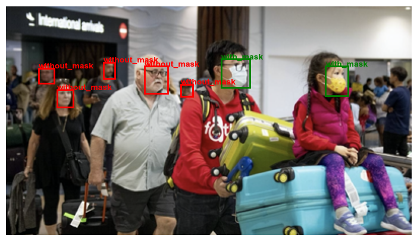

```python
face_cas(img_names[244])
```

#### The annotations of the image above

```python
with open(path_annotations+img_names[244][:-4]+".xml") as fd:
    doc=xmltodict.parse(fd.read())
temp=doc["annotation"]["object"]
print(temp)
```

```
[{'name': 'with_mask', 'pose': 'Unspecified', 'truncated': '0', 'occluded': '0', 'difficult': '0', 'bndbox': {'xmin': '315', 'ymin': '59', 'xmax': '337', 'ymax': '88'}}, {'name': 'with_mask', 'pose': 'Unspecified', 'truncated': '0', 'occluded': '0', 'difficult': '0', 'bndbox': {'xmin': '212', 'ymin'…
```

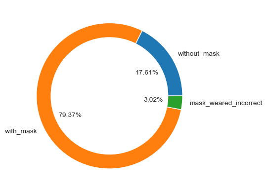

```python
plt.pie(values,wedgeprops=dict(width=0.2, edgecolor='w') ,labels=Items, autopct='%1.2f%%')
plt.show()
```

###### The first dataset contains 853 images. Each image is annotated by three labels. The total number and the ratio of each keys is shown here.

dict_keys(['without_mask', 'with_mask', 'mask_weared_incorrect']) dict_values([717, 3232, 123])

### The objective is to train the CNN model with dataset (face-mask-12k-images-dataset), then using pre-trained face detection model to detect the faces in images from dataset (face-mask-detection), identity if these faces are wearing facemask.

# Face Detection

Haarcascade_frontalfaces a pre-trained cascade classifier in OpenCV for detecting frontal faces in images or video frames. The classifier is based on the Haar-like features algorithm, which is a type of feature descriptor used in computer vision for object detection.

```python
face_model = cv2.CascadeClassifier(r"D:\ana\envs\tensorflow_test\Lib\site-packages\cv2\data\haarcascade_frontalface_default.xml")
#face_model = cv2.CascadeClassifier('haarcascade_frontalface_default.xml')
#face_model = cv2.CascadeClassifier(cv2.data.haarcascades + 'haarcascade_frontalface_default.xml')
```

```python
img = cv2.imread('D:\Desktop\mask\data\images/maksssksksss244.png')
img = cv2.cvtColor(img, cv2.IMREAD_GRAYSCALE)
faces = face_model.detectMultiScale(img,scaleFactor=1.1, minNeighbors=3)
out_img = cv2.cvtColor(img, cv2.COLOR_RGB2BGR)
```

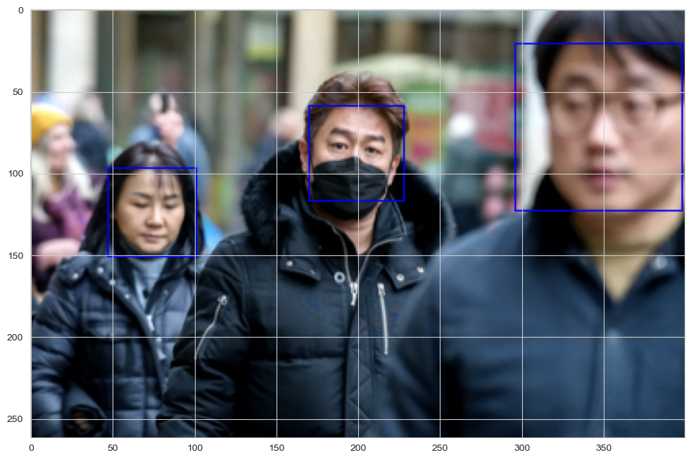

```python
for (x,y,w,h) in faces:
    cv2.rectangle(out_img,(x,y),(x+w,y+h),(0,0,255),1)
plt.figure(figsize=(12,12))
plt.imshow(out_img)
```

###### The function “detect_mask” is to uses a pre-trained deep learning model to detect faces in an image and classify them as wearing a mask or not. The function takes two inputs: the input image and the pre-trained deep learning model.

```python
mask_label = {0:'MASK',1:'NO MASK'}
color_label = {0:(0,255,0),1:(255,0,0)}
```

```python
def detect_mask(img,model):
    img = cv2.cvtColor(img, cv2.IMREAD_GRAYSCALE)
    #face_model = cv2.CascadeClassifier(r"D:\ana\envs\tensorflow_test\Lib\site-packages\cv2\data\haarcascade_frontalface_default.xml")
    faces = face_model.detectMultiScale(img,scaleFactor=1.1, minNeighbors=3)
    if len(faces)>=1:
        new_img = cv2.cvtColor(img, cv2.COLOR_RGB2BGR)
        for i in range(len(faces)):
            (x,y,w,h) = faces[i]
            crop = new_img[y:y+h,x:x+w]
            crop = cv2.resize(crop,(128,128))
            crop = np.reshape(crop,[1,128,128,3])/255.0
            mask_result = model.predict(crop)
            cv2.putText(new_img,mask_label[mask_result.argmax()],(x, y-10),cv2.FONT_HERSHEY_SIMPLEX,0.5,color_label[mask_result.argmax()],2)
            cv2.rectangle(new_img,(x,y),(x+w,y+h),color_label[mask_result.argmax()],1)
        plt.figure(figsize=(10,10))
        plt.imshow(new_img)

    else:
        print("No. of faces detected is less than 1")
```

# Model Training & Testing

```python
from keras.applications.vgg19 import VGG19
from keras.applications.vgg19 import preprocess_input
from keras import Sequential
from keras.layers import Flatten, Dense
from keras.preprocessing.image import ImageDataGenerator
from keras.preprocessing.image import load_img
```

### Prepare the data

We implement ImageDataGenerator in Keras to generate batches of image data with real-time data augmentation. We apply various image transformations such as shearing, zooming, shifting, to augment the available image data to increase the diversity of the dataset and prevent overfitting.

```python
train_dir = 'D:\Desktop\mask\Face Mask Dataset\Train'
test_dir = 'D:\Desktop\mask\Face Mask Dataset\Test'
val_dir = 'D:\Desktop\mask\Face Mask Dataset\Validation'
```

```python
train_datagen = ImageDataGenerator(rescale=1.0/255, horizontal_flip=True, zoom_range=0.2,shear_range=0.2, rotation_range=40)
train_generator = train_datagen.flow_from_directory(directory=train_dir,target_size=(128,128),class_mode='categorical',batch_size=32)

val_datagen = ImageDataGenerator(rescale=1.0/255)
val_generator = train_datagen.flow_from_directory(directory=val_dir,target_size=(128,128),class_mode='categorical',batch_size=32)

test_datagen = ImageDataGenerator(rescale=1.0/255)
test_generator = train_datagen.flow_from_directory(directory=val_dir,target_size=(128,128),class_mode='categorical',batch_size=32)
```

```
Found 10000 images belonging to 2 classes.
Found 800 images belonging to 2 classes.
Found 800 images belonging to 2 classes.
```

#### In this notebook we are using the VGG19 pre-trained model.

#### It is quite similar to the VGG16 model, with the only difference being that it has three extra convolution layers.

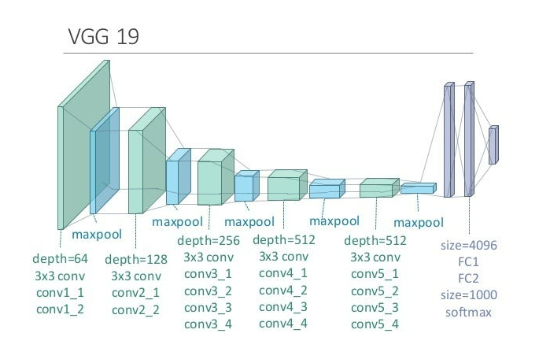

```python
vgg19 = VGG19(weights='imagenet',include_top=False,input_shape=(128,128,3))

for layer in vgg19.layers:
    layer.trainable = False

model_vgg = Sequential()
model_vgg.add(vgg19)
model_vgg.add(Flatten())
model_vgg.add(Dense(2,activation='sigmoid'))
model_vgg.summary()
```

```
Model: "sequential_2"
_________________________________________________________________
Layer (type)                 Output Shape              Param #
=================================================================
vgg19 (Functional)           (None, 4, 4, 512)         20024384
_________________________________________________________________
flatten_8 (Flatten)          (None, 8192)              0
_________________________________________________________________
dense_8 (Dense)              (None, 2)                 16386
=================================================================
Total params: 20,040,770
Trainable params: 16,386
Non-trainable params: 20,024,384
_________________________________________________________________
```

```python
model_vgg.compile(optimizer="adam",loss="categorical_crossentropy",metrics ="accuracy")
```

```python
history = model_vgg.fit_generator(generator=train_generator,
                              steps_per_epoch=len(train_generator)//32,
                              epochs=10,validation_data=val_generator,
                              validation_steps=len(val_generator)//32)
```

```python
model_vgg.evaluate_generator(test_generator)
```

```
[0.13600605726242065, 0.9537500143051147]
```

```python
img = cv2.imread('D:\Desktop\mask\data\images/maksssksksss244.png')
model = model_vgg
```

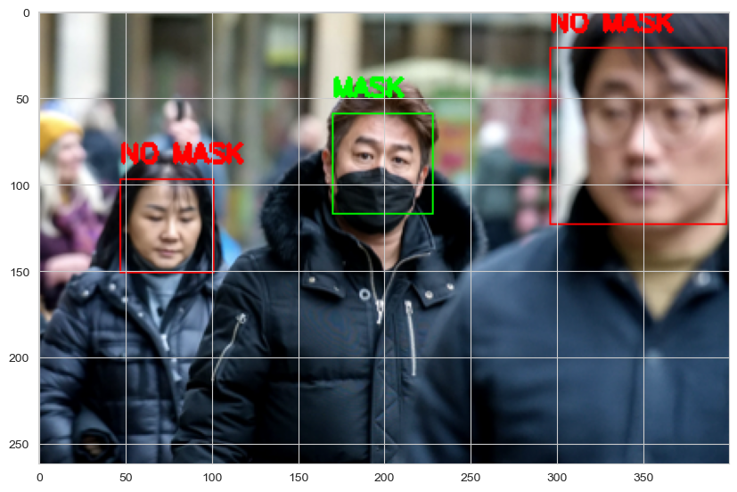

```python
detect_mask(img,model)
```

#### VGG have got a satisfied result. Next we will create cnn layers ourselves and explore the model.

### Model Exploration

```python
from tensorflow import keras
from tensorflow.keras import layers
from keras.callbacks import EarlyStopping
```

```python
inputs = keras.Input(shape=(128,128,3))
x = layers.Conv2D(filters=32, kernel_size=3, activation="relu")(inputs)
x = layers.MaxPooling2D(pool_size=2)(x)
# x = layers.Conv2D(filters=64, kernel_size=3, activation="relu")(x)
# x = layers.MaxPooling2D(pool_size=2)(x)
#x = layers.Conv2D(filters=128, kernel_size=3, activation="relu")(x)
x = layers.Flatten()(x)
outputs = layers.Dense(2, activation="softmax")(x)
model = keras.Model(inputs=inputs, outputs=outputs)
```

```python
model.summary()
```

```
Model: "model_64"
_________________________________________________________________
Layer (type)                 Output Shape              Param #
=================================================================
input_68 (InputLayer)        [(None, 128, 128, 3)]     0
_________________________________________________________________
conv2d_165 (Conv2D)          (None, 126, 126, 32)      896
_________________________________________________________________
max_pooling2d_113 (MaxPoolin (None, 63, 63, 32)        0
_________________________________________________________________
flatten_67 (Flatten)         (None, 127008)            0
_________________________________________________________________
dense_67 (Dense)             (None, 2)                 254018
=================================================================
Total params: 254,914
Trainable params: 254,914
Non-trainable params: 0
_________________________________________________________________
```

```python
early_stop = EarlyStopping(monitor='val_loss', min_delta=0.01, patience=5, restore_best_weights=True)
model.compile(optimizer="adam",loss="categorical_crossentropy",metrics ="accuracy")
```

```python
history = model.fit_generator(generator=train_generator,
                              steps_per_epoch=len(train_generator)//16,
                              epochs=20,validation_data=val_generator,
                              validation_steps=len(val_generator)//16,verbose=1,callbacks=[early_stop])
```

```python
accuracy = model.evaluate_generator(test_generator)[1]
```

[figure not shown]

```python
plt.plot(history.history['loss'], label='Training Loss')
plt.plot(history.history['val_loss'], label='Validation Loss')
plt.title('Model Loss')
plt.ylabel('Loss')
plt.xlabel('Epoch')
plt.legend()
plt.show()
```

```python
accuracy_kernel_3 = accuracy
```

### Kernel Sizes

```python
inputs = keras.Input(shape=(128,128,3))
x = layers.Conv2D(filters=32, kernel_size=5, activation="relu")(inputs)
x = layers.MaxPooling2D(pool_size=2)(x)
# x = layers.Conv2D(filters=64, kernel_size=3, activation="relu")(x)
# x = layers.MaxPooling2D(pool_size=2)(x)
#x = layers.Conv2D(filters=128, kernel_size=3, activation="relu")(x)
x = layers.Flatten()(x)
outputs = layers.Dense(2, activation="softmax")(x)
```

```python
model_kernel_5 = keras.Model(inputs=inputs, outputs=outputs)
early_stop = EarlyStopping(monitor='val_loss', min_delta=0.01, patience=5, restore_best_weights=True)
model_kernel_5.compile(optimizer="adam",loss="categorical_crossentropy",metrics ="accuracy")
```

```python
history_kernel_5 = model_kernel_5.fit_generator(generator=train_generator,
                              steps_per_epoch=len(train_generator)//32,
                              epochs=20,validation_data=val_generator,
                              validation_steps=len(val_generator)//
                              4,verbose=1,callbacks=[early_stop])
```

```python
accuracy_kernel_5 = model_kernel_5.evaluate_generator(test_generator)[1]
print(accuracy_kernel_5)
```

```
0.9337499737739563
```

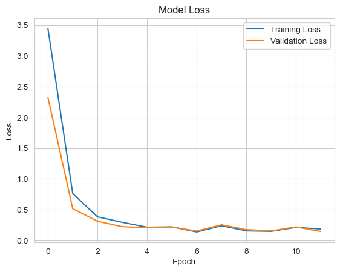

```python
plt.plot(history_kernel_5.history['loss'], label='Training Loss')
plt.plot(history_kernel_5.history['val_loss'], label='Validation Loss')
plt.title('Model Loss')
plt.ylabel('Loss')
plt.xlabel('Epoch')
plt.legend()
plt.show()
```

```python
inputs = keras.Input(shape=(128,128,3))
x = layers.Conv2D(filters=32, kernel_size=7, activation="relu")(inputs)
x = layers.MaxPooling2D(pool_size=2)(x)
# x = layers.Conv2D(filters=64, kernel_size=3, activation="relu")(x)
# x = layers.MaxPooling2D(pool_size=2)(x)
#x = layers.Conv2D(filters=128, kernel_size=3, activation="relu")(x)
x = layers.Flatten()(x)
outputs = layers.Dense(2, activation="softmax")(x)
```

```python
model_kernel_7 = keras.Model(inputs=inputs, outputs=outputs)
early_stop = EarlyStopping(monitor='val_loss', min_delta=0.01, patience=5, restore_best_weights=True)
model_kernel_7.compile(optimizer="adam",loss="categorical_crossentropy",metrics ="accuracy")
model_kernel_7.summary()
```

```
Model: "model_63"
_________________________________________________________________
Layer (type)                 Output Shape              Param #
=================================================================
input_67 (InputLayer)        [(None, 128, 128, 3)]     0
_________________________________________________________________
conv2d_164 (Conv2D)          (None, 122, 122, 32)      4736
_________________________________________________________________
max_pooling2d_112 (MaxPoolin (None, 61, 61, 32)        0
_________________________________________________________________
flatten_66 (Flatten)         (None, 119072)            0
_________________________________________________________________
dense_66 (Dense)             (None, 2)                 238146
=================================================================
Total params: 242,882
Trainable params: 242,882
Non-trainable params: 0
_________________________________________________________________
```

```python
history_kernel_7 = model_kernel_7.fit_generator(generator=train_generator,
                              steps_per_epoch=len(train_generator)//32,
                              epochs=20,validation_data=val_generator,
                              validation_steps=len(val_generator)//
                              4,verbose=1,callbacks=[early_stop])
```

```python
accuracy_kernel_7 = model_kernel_7.evaluate_generator(test_generator)[1]
```

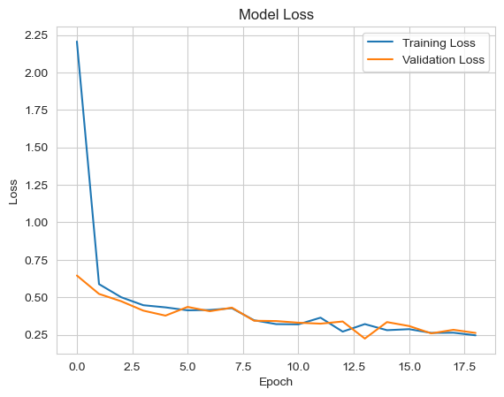

```python
plt.plot(history_kernel_7.history['loss'], label='Training Loss')
plt.plot(history_kernel_7.history['val_loss'], label='Validation Loss')
plt.title('Model Loss')
plt.ylabel('Loss')
plt.xlabel('Epoch')
plt.legend()
plt.show()
```

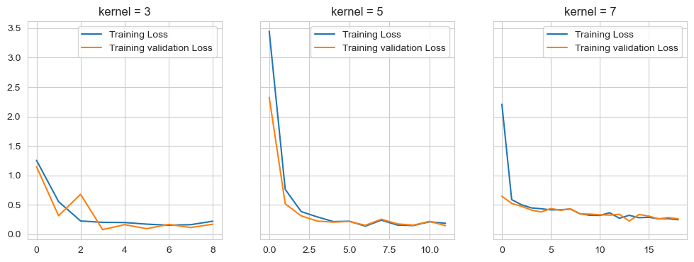

```python
fig, axs = plt.subplots(1, 3,figsize=(12, 4), sharey=True)
axs[0].plot(history.history['loss'], label='Training Loss')
axs[0].plot(history.history['val_loss'], label='Training validation Loss')
axs[0].legend()
axs[0].set_title('kernel = 3')
axs[1].plot(history_kernel_5.history['loss'], label='Training Loss')
axs[1].plot(history_kernel_5.history['val_loss'], label='Training validation Loss')
axs[1].legend()
axs[1].set_title('kernel = 5')
axs[2].plot(history_kernel_7.history['loss'], label='Training Loss')
axs[2].plot(history_kernel_7.history['val_loss'], label='Training validation Loss')
axs[2].legend()
axs[2].set_title('kernel = 7')
```

```python
accuracy_kernel = pd.DataFrame(columns=["Kernel","Accuracy"])
kernel = [3,5,7]
```

```python
for i in range(len(kernel)):
    var_name = f"accuracy_kernel_{kernel[i]}"
    accuracy_kernel.loc[i] = [kernel[i], globals()[var_name]]
```

```python
print(accuracy_kernel)
```

```
   Kernel  Accuracy
0     3.0   0.96625
1     5.0   0.93375
2     7.0   0.89875
```

Then we test different parameters and discuss their influence.

## Fine Tuning

```python
This is an error, in order to stop running code here.

num_filters = [32, 64, 128]
kernel_sizes = [3, 5]
activations = ["relu", "sigmoid"]
learning_rates = [0.001, 0.01]
epochs = [10, 20]

results_df = pd.DataFrame(columns=["Num Filters", "Kernel Size", "Activation", "Learning Rate", "Epochs", "Train Loss", "Val Loss", "Train Acc", "Val Acc"])

for nf in num_filters:
    for ks in kernel_sizes:
        for act in activations:
            for lr in learning_rates:
                for ep in epochs:
                    inputs = keras.Input(shape=(128,128,3))
                    x = layers.Conv2D(filters=nf, kernel_size=ks, activation=act)(inputs)
                    x = layers.MaxPooling2D(pool_size=2)(x)
                    x = layers.Conv2D(filters=nf*2, kernel_size=ks, activation=act)(x)
                    x = layers.MaxPooling2D(pool_size=2)(x)
                    x = layers.Conv2D(filters=nf*4, kernel_size=ks, activation=act)(x)
                    x = layers.Flatten()(x)
                    outputs = layers.Dense(2, activation="softmax")(x)
                    model = keras.Model(inputs=inputs, outputs=outputs)

                    optimizer = keras.optimizers.Adam(lr=lr)
                    model.compile(optimizer=optimizer, loss="categorical_crossentropy", metrics=["accuracy"])

                    history = model.fit_generator(generator=train_generator,
                                                  steps_per_epoch=len(train_generator)//32,
                                                  epochs=ep,
                                                  validation_data=val_generator,
                                                  validation_steps=len(val_generator)//32)

                    results_df = results_df.append({"Num Filters": nf,
                                                    "Kernel Size": ks,
                                                    "Activation": act,
                                                    "Learning Rate": lr,
                                                    "Epochs": ep,
                                                    "Train Loss": history.history["loss"][-1],
                                                    #"Val Loss": history.history["val_loss"][-1],
                                                    "Train Acc": history.history["accuracy"][-1]},
                                                    #"Val Acc": history.history["val_accuracy"][-1]},
                                                    ignore_index=True)

print(results_df)
```

```
   Num Filters Kernel Size Activation  Learning Rate Epochs  Train Loss  \
0           32           3       relu          0.001     10    0.127947
1           32           3       relu          0.001     20    0.164526
2           32           3       relu          0.010     10    0.706942
3           32           3       relu          0.010     20    0.226474
4           32           3    sigmoid          0.001     10    0.692802
5           32           3    sigmoid          0.001     20    0.693277
6           32           3    sigmoid          0.010     10    0.692700
7           32           3    sigmoid          0.010     20    0.692373
8           32           5       relu          0.001     10    0.163348
9           32           5       relu          0.001     20    0.128811
10          32           5       relu          0.010     10    0.698243
11          32           5       relu          0.010     20    0.726464
12          32           5    sigmoid          0.001     10    0.693133
13          32           5    sigmoid          0.001     20    0.694198
```

[output cut: 84 more lines]

```python
s = results_df.to_string(index=False)
print(s)
```

```
Num Filters Kernel Size Activation  Learning Rate Epochs  Train Loss  Train Acc
         32           3       relu          0.001     10    0.127947   0.961806
         32           3       relu          0.001     20    0.164526   0.947917
         32           3       relu          0.010     10    0.706942   0.503472
         32           3       relu          0.010     20    0.226474   0.909722
         32           3    sigmoid          0.001     10    0.692802   0.534722
         32           3    sigmoid          0.001     20    0.693277   0.496528
         32           3    sigmoid          0.010     10    0.692700   0.552083
         32           3    sigmoid          0.010     20    0.692373   0.524306
         32           5       relu          0.001     10    0.163348   0.947917
         32           5       relu          0.001     20    0.128811   0.954861
         32           5       relu          0.010     10    0.698243   0.482639
         32           5       relu          0.010     20    0.726464   0.468750
         32           5    sigmoid          0.001     10    0.693133   0.531250
         32           5    sigmoid          0.001     20    0.694198   0.447917
```

[output cut: 34 more lines]

```python
results_df1= results_df.sort_values(by='Train Acc',ascending=False)
s = results_df1.to_string(index=False)
print(s)
```

```
Num Filters Kernel Size Activation  Learning Rate Epochs  Train Loss  Train Acc
         32           3       relu          0.001     10    0.127947   0.961806
         64           3       relu          0.001     20    0.126978   0.961806
         32           5       relu          0.001     20    0.128811   0.954861
         32           5       relu          0.001     10    0.163348   0.947917
         32           3       relu          0.001     20    0.164526   0.947917
         64           5       relu          0.001     10    0.192297   0.923611
        128           5       relu          0.001     10    0.314821   0.916667
        128           5       relu          0.001     20    0.233752   0.913194
         32           3       relu          0.010     20    0.226474   0.909722
        128           3       relu          0.001     10    0.231511   0.902778
        128           3       relu          0.001     20    0.303658   0.899306
         64           3       relu          0.001     10    0.307329   0.895833
         64           5       relu          0.001     20    0.570448   0.843750
        128           3    sigmoid          0.010     10  117.821869   0.565972
```

[output cut: 34 more lines]

## Conclusion

Num Filters: The number of filters is the Depth of the output feature map, computed by the convolution. 32 filters have enough capacity to learn complex representations of this input data. Too many filters may overfit to the training data.

Activation: Data has shown that ReLU outperforms sigmoid in deep neural networks, particularly in image classification tasks. This is partly due to the fact that ReLU can better handle large and complex datasets, and partly due to its ability to capture more complex patterns and representations in the input data. Also, it is more computationally efficient and avoids the vanishing gradient problem(Check the train loss up there)

Learning Rate: A smaller learning rate has an overwhelming advantage. Apparently, small step size allows the optimizer to carefully search the parameter space and avoid overshooting the optimal solution. When the learning rate is too large, the optimizer may oscillate around the optimal solution or even diverge.

```python
#results_df.to_csv('results_df.csv', index=False)
```

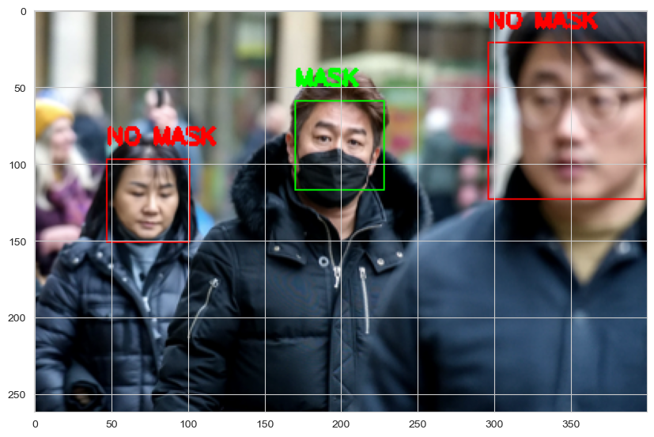

```python
detect_mask(img,model_kernel_7)
```

References: https://www.kaggle.com/code/nageshsingh/mask-and-social-distancing-detection-using-vgg19 https://www.kaggle.com/code/asdfghj4556/pytorch-fasterrcnn